# STA207 Final Report

Group 9

2026-03-10

# Background

In the American K-12 education system, the impact of class size on student academic achievement is a significant and widely considered issue. To explore this, the Tennessee State Department of Education launched the Student/Teacher Achievement Ratio (STAR) project, a four-year longitudinal study from 1985 to 1989. The data used in this project are publicly archived on Harvard Dataverse. All schools were invited to participate, and over 7,000 students in 79 schools were randomly assigned to one of three groups: small class (13-17 students), regular classes (22-25 students), and regular classes with a full-time teacher’s aide (22-25 students +aide). In order to ensure the results were unbiased, teachers were also randomly assigned to these three groups. The study tracked students from their entry in kindergarten through the end of the third grade.

### Randomized experiment

Within each participating school, students were assigned at random to one of three groups, and teachers were also randomly assigned to classes:

##### Small class (S): 13-17 students

##### Regular class ( R): 22-25 students

##### Regular classes + full-time teacher’s aide(RA): 22-25 students +aide

The random grouping work was handled and supervised by the STAR Consortium. The user’s guide mentioned that systematic biases (such as gender, composition of free lunch, etc.) had been checked, and it was reported that no signs of systematic biases were found in the random grouping process.

### Caveats relevant for analyzing grades 1–3 achievement effects

From the user’s guide, we extracted three relevant caveats that should be considered in our future analysis:

##### Not all students have the same exposure length

Kindergarten was not legally mandated in Tennessee at the time of doing this study, and many students entered the STAR sample in the first grade. Some students left STAR schools before third grade. This shows that the “small class” can vary across students.

##### Modifying the Regular and Regular+aide classes

After kindergarten, approximately half of the Regular students were reassigned to Regular+aide, and vice versa. Small class students were not purposely reassigned into or out of small classes.

##### Mobility and “class size changing.

Student movement changed actual enrollments, and regular classes could sometimes become as small as small classes. In the second study year, students enrolling at the first-grade level were randomly assigned to one of the three predetermined groups.

To address the issue that not all students had the same exposure time, we restricted our analysis to students who participated in the experiment from K1 to K3. Since there had been no significant differences in the achievement of R and RA classes in the kindergarten year, the rearrangement after the kindergarten does not influence our analysis. And then we consider including school effects because the mobility and class-size changes may differ across schools.

# Question of Interest

We are interested in whether assignment to a smaller class improves the academic performance of students in grades 1–3, measured by Stanford Achievement Test (SAT) scores, using data from Tennessee’s Project STAR study.

This question matters because demonstrating causal relationships in education is both very beneficial to society and very difficult to achieve. Setting up a small, new classroom usually requires an initial investment of over $1,000 for basic, immediate supplies, while comprehensive, high-quality, or specialized classroom start up grants can range from $10,000 up to $20,000 per semester. Teachers typically spend over $500 to $860 each year on purchasing supplies, and a brand new, complete small preschool-style facility may cost $350,000 to $600,000. This expenditure will vary in accordance with the local economic trends and other external factors.

We want to know if it is worth spending time and money on implementing small-class teaching. By demonstrating the causal impact of decisions such as class size, school officials can make more informed decisions about how to design educational programs. Ideally, this causal effect can be applied more broadly to improve student test performance.

Project STAR is especially well-suited to our question since students were randomly assigned within schools to small classes, rather than regular classes, which helps to ensure that differences in SAT scores can be interpreted as causal effects of class size rather than correlations driven by family background, school selection, or other elements.

# Descriptive Analysis

### Exploratory Data Analysis:

##### Sample structure and attrition

| Group | Number of Students | Percentage of Total |
| --- | --- | --- |
| Full Dataset | 11601 | 100.00 |
| K through 4th grade | 2863 | 24.68 |
| K through 4th grade, same class type | 1556 | 13.41 |
| 1st through 3rd grade, same class type | 3423 | 29.51 |
| 1st through 3rd grade, same class type, same school | 3382 | 29.15 |

##### Outcome choice: SAT vs. BSF (Basic Skills First)

SAT was developed by the Psychological Corporation, which is a nationally formed, standardized achievement test, and BSF is a Tennessee state test aligned to state learning objectives, this indicates that the SAT is more comprehensive than BSF.

For our analysis, academic performance is measured by using the Stanford Achievement Test (SAT) scale scores for the following three reasons. First, compared with the BSF, SAT scores appear approximately bell-shaped and better for standard linear modeling. Second, the SAT measures students at three levels( listening, math, and reading); however, the BSF measures two(math and reading). Third, BSF scores cannot be compared from one grade to another because the number of objectives varies from grade to grade (some of them are lost).

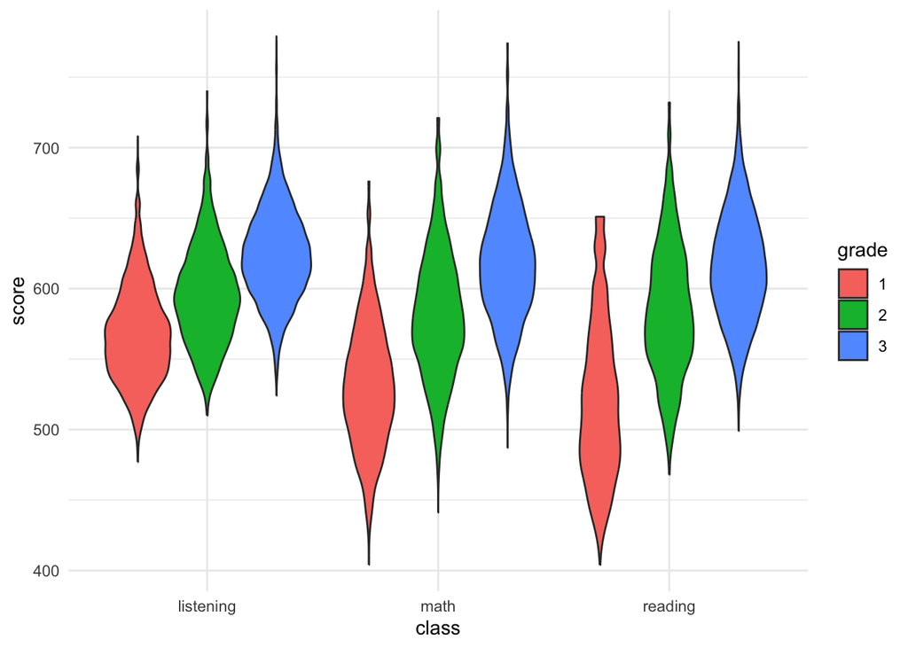

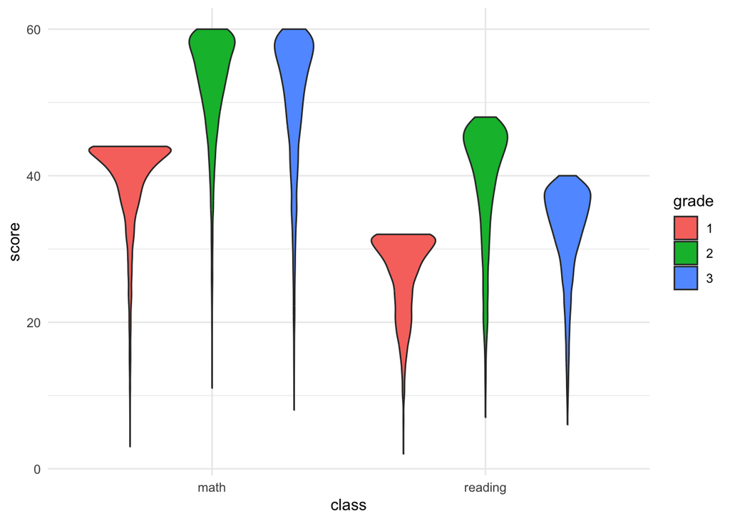

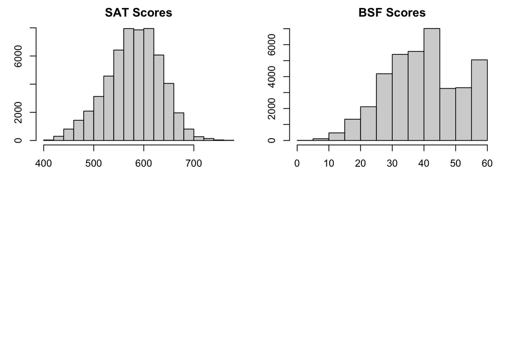

##### Reconstruct the data into a long format

SAT scores vary systematically by grade level and subject area. So we convert the data to a long format where grade level and subject are factors to control for. This is straightforward to summarize outcomes by grade and subject, and include grade and subject effects directly in the model to avoid confounding comparisons across different test scales or grade-level distributions.

##### Subset Dataset

After we finished the EDA, we reconstructed our data as a subset data set. In this subset dataset, we include the following variables for doing the future analysis.

# Inferential Analysis

#### Model 1: Multiple Linear Regression Model without interaction term from our EDA

Our goal is to estimate the causal effect of being assigned to a small class on academic performance, measured by Stanford Achievement Test (SAT) scale scores, for students in grades 1–3 in Project STAR. From the EDA, we extract our subset data. Next, we want to verify if our selected variables are effectively related to scores.

$$\text{score}_i
= \alpha_0
+ \sum_j \alpha_{1j}(\text{class type})_{ij}
+ \sum_j \alpha_{2j}(\text{gender})_{ij}
+ \sum_j \alpha_{3j}(\text{race})_{ij}
+ \sum_j \alpha_{4j}(\text{subject})_{ij}\\
+ \sum_j \alpha_{5j}(\text{grade})_{ij}
+ \sum_j \alpha_{6j}(\text{urban})_{ij}
+ \varepsilon_i$$

```
## # A tibble: 6 × 9
##   stdntid gender race  class_type   score subject   grade schid  urban
##     <dbl> <fct>  <fct> <fct>        <dbl> <fct>     <fct> <fct>  <fct>
## 1   10000 male   white regular_plus   516 reading   1     170295 rural
## 2   10000 male   white regular_plus   578 math      1     170295 rural
## 3   10000 male   white regular_plus   601 listening 1     170295 rural
## 4   10000 male   white regular_plus   547 reading   2     170295 rural
## 5   10000 male   white regular_plus   577 math      2     170295 rural
## 6   10000 male   white regular_plus   572 listening 2     170295 rural
```

```
##
## Call:
## lm(formula = score ~ class_type + subject + gender + race + grade +
##     urban, data = df_subset)
##
## Residuals:
##      Min       1Q   Median       3Q      Max
## -146.779  -26.630   -1.805   24.488  160.350
##
## Coefficients:
##                        Estimate Std. Error t value Pr(>|t|)
## (Intercept)            576.6354     4.7200 122.168  < 2e-16 ***
## class_typeregular_plus   1.7111     0.5615   3.047 0.002312 **
## class_typesmall          8.8677     0.5737  15.458  < 2e-16 ***
## subjectmath            -17.0796     0.5539 -30.838  < 2e-16 ***
## subjectreading         -18.1856     0.5558 -32.719  < 2e-16 ***
## gendermale              -1.5702     0.4538  -3.460 0.000540 ***
## raceblack              -39.4015     4.6410  -8.490  < 2e-16 ***
## racehispanic           -11.1117     8.1931  -1.356 0.175039
## raceother               -0.2655     8.8000  -0.030 0.975930
## racewhite              -16.4785     4.6026  -3.580 0.000344 ***
## grade2                  43.0146     0.5535  77.710  < 2e-16 ***
## grade3                  73.0656     0.5549 131.666  < 2e-16 ***
## urbanrural               6.5528     0.9867   6.641 3.17e-11 ***
## urbansuburban            8.7689     0.9486   9.244  < 2e-16 ***
## urbanurban               3.8144     1.2320   3.096 0.001963 **
## ---
## Signif. codes:  0 '***' 0.001 '**' 0.01 '*' 0.05 '.' 0.1 ' ' 1
##
## Residual standard error: 38.95 on 29528 degrees of freedom
##   (895 observations deleted due to missingness)
## Multiple R-squared:  0.4215, Adjusted R-squared:  0.4212
## F-statistic:  1537 on 14 and 29528 DF,  p-value: < 2.2e-16
```

### Assumptions

- **Linearity**: The expected relationship between the predictors and SAT scores is linear.
- **Independence**: Observations are independent across students.
- **Homoscedasticity**: The error terms have constant variance across fitted values or predictor levels.
- **Normality**: The residuals are approximately normally distributed.

Here, $\text{score}_i$ denotes the SAT score for student $i$, and $\alpha_0$ is the intercept. The terms for class type, gender, race, subject, grade, and urbanicity represent the contribution of these categorical predictors to the expected score. Because these variables are categorical, they are included in the model through indicator (dummy) variables. The term $\varepsilon_i$ denotes the random error for student $i$.

#### Model 2: Multiple Linear Regression Model with interaction term from our EDA

$$\text{score}_i
= \alpha_0
+ \sum_j \alpha_{1j}(\text{class type})_{ij}
+ \sum_j \alpha_{2j}(\text{gender})_{ij}
+ \sum_j \alpha_{3j}(\text{race})_{ij}
+ \sum_j \alpha_{4j}(\text{subject})_{ij}\\
+ \sum_j \alpha_{5j}(\text{grade})_{ij}
+ \sum_j \alpha_{6j}(\text{urban})_{ij}
+ \sum_{a,b} \alpha_{7ab}(\text{subject})_{ia}(\text{grade})_{ib}
+ \varepsilon_i$$
Including the interaction of subject and grade significantly reduced the curvature of the residuals versus fitted values plot, so we include this interaction term for the following models.

```
##
## Call:
## lm(formula = score ~ class_type + subject + gender + grade +
##     urban + race + subject * grade, data = df_subset)
##
## Residuals:
##      Min       1Q   Median       3Q      Max
## -151.587  -25.842   -2.249   24.094  155.544
##
## Coefficients:
##                        Estimate Std. Error t value Pr(>|t|)
## (Intercept)            589.2875     4.6704 126.174  < 2e-16 ***
## class_typeregular_plus   1.7086     0.5532   3.089 0.002011 **
## class_typesmall          8.8796     0.5651  15.713  < 2e-16 ***
## subjectmath            -33.8422     0.9370 -36.117  < 2e-16 ***
## subjectreading         -39.4829     0.9441 -41.821  < 2e-16 ***
## gendermale              -1.5712     0.4470  -3.515 0.000441 ***
## grade2                  25.6380     0.9434  27.175  < 2e-16 ***
## grade3                  52.2697     0.9441  55.365  < 2e-16 ***
## urbanrural               6.5325     0.9720   6.721 1.84e-11 ***
## urbansuburban            8.7559     0.9344   9.371  < 2e-16 ***
## urbanurban               3.8224     1.2136   3.150 0.001637 **
## raceblack              -39.4187     4.5717  -8.622  < 2e-16 ***
## racehispanic           -11.1061     8.0709  -1.376 0.168814
## raceother               -0.2631     8.6687  -0.030 0.975789
## racewhite              -16.4951     4.5339  -3.638 0.000275 ***
## subjectmath:grade2      20.9913     1.3329  15.748  < 2e-16 ***
## subjectreading:grade2   31.3082     1.3377  23.405  < 2e-16 ***
## subjectmath:grade3      29.7311     1.3345  22.280  < 2e-16 ***
## subjectreading:grade3   32.8994     1.3417  24.521  < 2e-16 ***
## ---
## Signif. codes:  0 '***' 0.001 '**' 0.01 '*' 0.05 '.' 0.1 ' ' 1
##
## Residual standard error: 38.37 on 29524 degrees of freedom
##   (895 observations deleted due to missingness)
## Multiple R-squared:  0.4387, Adjusted R-squared:  0.4384
## F-statistic:  1282 on 18 and 29524 DF,  p-value: < 2.2e-16
```

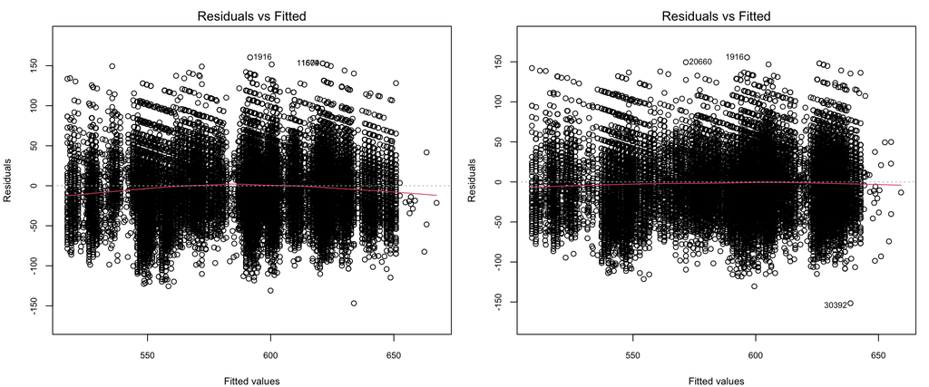

These are Residuals vs Fitted diagnostic plots for two regression specifications (left: no interaction, right: with interaction). The red line represents the LOESS smoothed trend line of the residuals relative to the fitted values, which is used to check if there is any systematic bias in the model. Compared to the model without interaction, after adding the interaction term, the red line is closer to the horizontal line and closer to zero, indicating that the interaction term helps the model better explain the differences in different groups and reduces the structural patterns in the residuals. Including the interaction of subject and grade significantly reduced the curvature of the residuals versus fitted values plot, so we include this interaction term for the following models.

### ANOVA (Type III Sum of Squares)

We ran the ANOVA model using type III Sum of Squares to see if all the predictors are highly contributing to the prediction of the scores. Type III provides partial (marginal) F-tests, asking whether removing a given predictor is included. The small p-values indicate that the corresponding predictor remains significantly associated with SAT scores after controlling for the others. The interaction of subject and grade suggests that subject differences vary by grade, that supporting our add interaction terms into our model.

The interaction term subject*grade indeed improves the performance of the model, as the residual sum of squares decreases and with very small p-value.

```
## Anova Table (Type III tests)
##
## Response: score
##                 Sum Sq    Df   F value    Pr(>F)
## (Intercept)   23433415     1 15919.796 < 2.2e-16 ***
## class_type      426001     2   144.705 < 2.2e-16 ***
## subject        3032875     2  1030.211 < 2.2e-16 ***
## gender           18185     1    12.354 0.0004407 ***
## grade          4512064     2  1532.665 < 2.2e-16 ***
## urban           148730     3    33.681 < 2.2e-16 ***
## race           1436897     4   244.044 < 2.2e-16 ***
## subject:grade  1332294     4   226.278 < 2.2e-16 ***
## Residuals     43458354 29524
## ---
## Signif. codes:  0 '***' 0.001 '**' 0.01 '*' 0.05 '.' 0.1 ' ' 1
```

### Mixed effect models with student ID and school ID as random effects

After the Type III ANOVA suggested that each term (including the subject-grade interaction) contributes to explaining SAT scores, we moved to a mixed-effects model to better match the structure.

##### Assumptions

- **Linearity**: The conditional mean of SAT score is linear in the fixed-effect predictors (including the interaction terms).
- **Random effects distribution**: Student random intercepts are normally distributed.
- **Homoscedasticity**: Constant residual variance across fitted values/groups.
- **Normality**: Residuals are approximately normally distributed conditional on the random effects.
- **Independence**: Random effects are independent of the fixed predictors.

#### Model 3: Mixed Effect Model (with school as RE)

$$\text{score}_i
= \alpha_0
+ \sum_j \alpha_{1j}(\text{class type})_{ij}
+ \sum_j \alpha_{2j}(\text{gender})_{ij}
+ \sum_j \alpha_{3j}(\text{race})_{ij}
+ \sum_j \alpha_{4j}(\text{subject})_{ij}\\
+ \sum_j \alpha_{5j}(\text{grade})_{ij}
+ \sum_j \alpha_{6j}(\text{urban})_{ij}
+ \sum_{a,b} \alpha_{7ab}(\text{subject})_{ia}(\text{grade})_{ib}
+ \mu_{\text{school}(j)}
+ \varepsilon_i$$

```
## Linear mixed model fit by REML ['lmerMod']
## Formula: score ~ class_type + subject + gender + race + grade + subject *
##     grade + (1 | schid)
##    Data: df_subset
##
## REML criterion at convergence: 297307.1
##
## Scaled residuals:
##     Min      1Q  Median      3Q     Max
## -3.9478 -0.6791 -0.0543  0.6200  4.0348
##
## Random effects:
##  Groups   Name        Variance Std.Dev.
##  schid    (Intercept)  139.8   11.82
##  Residual             1363.9   36.93
## Number of obs: 29543, groups:  schid, 75
##
## Fixed effects:
##                        Estimate Std. Error t value
## (Intercept)            595.7369     4.6640 127.731
## class_typeregular_plus   0.7405     0.5476   1.352
## class_typesmall          9.4688     0.5570  16.999
## subjectmath            -33.8350     0.9020 -37.511
## subjectreading         -39.5270     0.9096 -43.454
## gendermale              -1.6024     0.4345  -3.688
## raceblack              -40.3288     4.4690  -9.024
## racehispanic           -11.6954     7.8843  -1.483
## raceother               -3.7611     8.4144  -0.447
## racewhite              -18.3226     4.4066  -4.158
## grade2                  25.5944     0.9090  28.157
## grade3                  52.2653     0.9088  57.508
## subjectmath:grade2      20.9910     1.2831  16.360
## subjectreading:grade2   31.3725     1.2883  24.353
## subjectmath:grade3      29.7020     1.2846  23.122
## subjectreading:grade3   32.8988     1.2915  25.473
```

```
##
## Correlation matrix not shown by default, as p = 16 > 12.
## Use print(x, correlation=TRUE)  or
##     vcov(x)        if you need it
```

Based on the previous multiple linear regression model, we considered adding school as a random effect to see if the effects of small class size are similar among all 75 schools. The differences in teaching quality, physical facilities, or school district background can vary across schools, and these factors can influence both class assignment and students’ academic performance. Therefore, we stratified schools to see if the effects of class sizes on scores are universal regardless of the grouping of the school.

Random effects

[output not shown]

#### Model 4: Mixed Effect Model (with student as RE)

$$\text{score}_i
= \alpha_0
+ \sum_j \alpha_{1j}(\text{class type})_{ij}
+ \sum_j \alpha_{2j}(\text{gender})_{ij}
+ \sum_j \alpha_{3j}(\text{race})_{ij}
+ \sum_j \alpha_{4j}(\text{subject})_{ij}\\
+ \sum_j \alpha_{5j}(\text{grade})_{ij}
+ \sum_j \alpha_{6j}(\text{urban})_{ij}
+ \sum_{a,b} \alpha_{7ab}(\text{subject})_{ia}(\text{grade})_{ib}
+ \mu_{\text{student}(j)}
+ \varepsilon_i$$

```
## Linear mixed model fit by REML ['lmerMod']
## Formula: score ~ class_type + subject + gender + race + grade + subject *
##     grade + (1 | stdntid)
##    Data: df_subset
##
## REML criterion at convergence: 282999.7
##
## Scaled residuals:
##     Min      1Q  Median      3Q     Max
## -3.7840 -0.6234 -0.0456  0.5595  5.7292
##
## Random effects:
##  Groups   Name        Variance Std.Dev.
##  stdntid  (Intercept) 857.9    29.29
##  Residual             633.9    25.18
## Number of obs: 29543, groups:  stdntid, 3382
##
## Fixed effects:
##                        Estimate Std. Error t value
## (Intercept)            597.0626    10.8148  55.208
## class_typeregular_plus   1.6093     1.2987   1.239
## class_typesmall          8.9145     1.3257   6.724
## subjectmath            -33.8351     0.6151 -55.011
## subjectreading         -39.9706     0.6205 -64.417
## gendermale              -1.6798     1.0508  -1.599
## raceblack              -43.3233    10.8332  -3.999
## racehispanic           -16.8647    18.7186  -0.901
## raceother               -1.0377    20.6363  -0.050
## racewhite              -17.6176    10.7920  -1.632
## grade2                  25.6072     0.6202  41.290
## grade3                  51.3673     0.6206  82.766
## subjectmath:grade2      20.9379     0.8749  23.933
## subjectreading:grade2   31.7702     0.8786  36.160
## subjectmath:grade3      29.6467     0.8760  33.844
## subjectreading:grade3   33.3462     0.8809  37.853
```

```
##
## Correlation matrix not shown by default, as p = 16 > 12.
## Use print(x, correlation=TRUE)  or
##     vcov(x)        if you need it
```

Since each student in our data (selected from the EDA) attended one school only, we further considered using student ID as a random effect instead, and each student has exactly 9 scores, from grade 1 to grade 3, three subjects each; the grouping is beneficial for us to account for the randomness at the student level. In this model, we can see how small class size affects each student after extracting the variation among all students (e.g., family, intelligence, favorite subjects, etc).

Random effects

| Groups | Name | Variance | Std.Dev. |
| --- | --- | --- | --- |
| stdntid | (Intercept) | 857.9 | 29.29 |
| Residual |  | 633.9 | 25.18 |

Comparing the model results, it is clearly to show that when the random effect is elevated from the school level to the student level, the residual variance drops from 1363 to 633. This indicates that the individual differences explain a large portion of the previously unexplained error. Furthermore, the coefficient for small class size remains stable at 8.91 and remains statistically significantly positive. In this way, we have confidence to say that the positive impact of a small class is not misleading by differences in students.

# Sensitivity Analysis

### Plausibility check

In order to evaluate whether our model assumptions are reasonable, we examined residual diagnostics. The residual-versus-fitted plot shows residuals scattered around zero with no clear systematic pattern across the range of fitted SAT scores, which supports the linearity of the mean structure. The plot shows that the overall vertical spread is fairly stable and has no obvious funnel shape. So homoscedasticity is plausible. We also inspected the histogram of residuals, which is roughly bell-shaped and centered near zero.

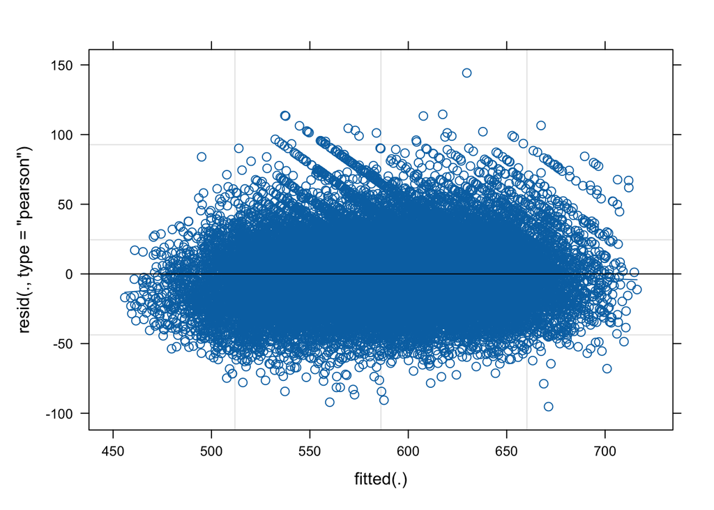

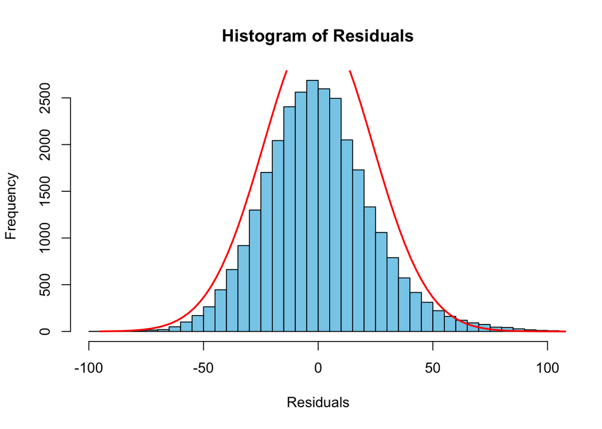

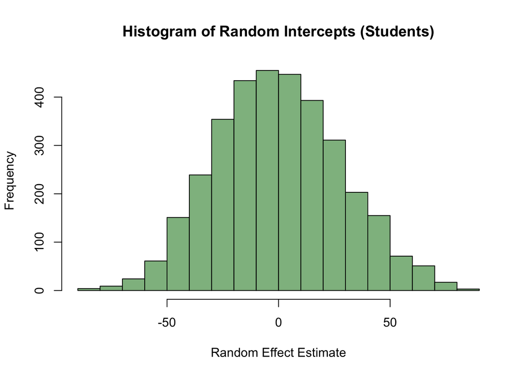

|  | Variance of Residual | Coefficient of small class |
| --- | --- | --- |
| Multiple Linear Regression Model without interaction term | 1517 | 8.867 |
| Multiple Linear Regression Model with interaction term | 1472 | 8.879 |
| Mixed Effect Model (school as random effect) | 1364 | 9.468 |
| Mixed Effect Model (student as random effect) | 634 | 8.915 |

### Key Decision: Final Mixed Effect Model with Student as Random Effect

$$\text{score}_i
= \alpha_0
+ \sum_j \alpha_{1j}(\text{class type})_{ij}
+ \sum_j \alpha_{2j}(\text{gender})_{ij}
+ \sum_j \alpha_{3j}(\text{race})_{ij}
+ \sum_j \alpha_{4j}(\text{subject})_{ij}\\
+ \sum_j \alpha_{5j}(\text{grade})_{ij}
+ \sum_j \alpha_{6j}(\text{urban})_{ij}
+ \sum_{a,b} \alpha_{7ab}(\text{subject})_{ia}(\text{grade})_{ib}
+ \mu_{\text{student}(j)}
+ \varepsilon_i$$

# Robustness check

We made two plots to check robustness.

By running the same model repeatedly and leaving each school once to check how the estimated coefficient for a small class fluctuates. We see that the coefficients range around 8.9, implying robustness.

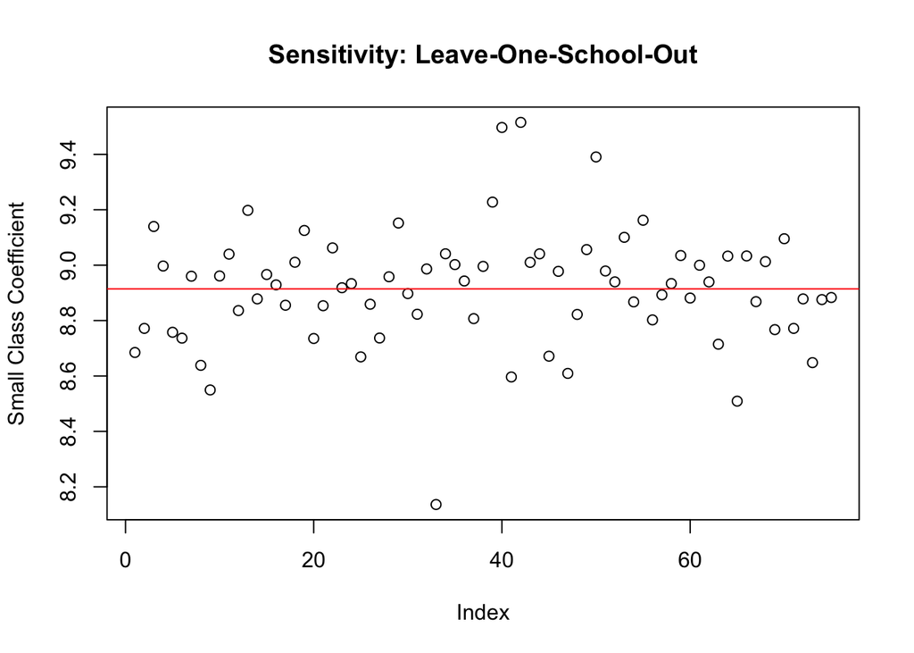

```
## # A tibble: 18 × 6
##    effect   group    term                   estimate std.error statistic
##    <chr>    <chr>    <chr>                     <dbl>     <dbl>     <dbl>
##  1 fixed    <NA>     (Intercept)              597.      10.8     55.2
##  2 fixed    <NA>     class_typeregular_plus     1.61     1.30     1.24
##  3 fixed    <NA>     class_typesmall            8.91     1.33     6.72
##  4 fixed    <NA>     subjectmath              -33.8      0.615  -55.0
##  5 fixed    <NA>     subjectreading           -40.0      0.620  -64.4
##  6 fixed    <NA>     gendermale                -1.68     1.05    -1.60
##  7 fixed    <NA>     raceblack                -43.3     10.8     -4.00
##  8 fixed    <NA>     racehispanic             -16.9     18.7     -0.901
##  9 fixed    <NA>     raceother                 -1.04    20.6     -0.0503
## 10 fixed    <NA>     racewhite                -17.6     10.8     -1.63
## 11 fixed    <NA>     grade2                    25.6      0.620   41.3
## 12 fixed    <NA>     grade3                    51.4      0.621   82.8
## 13 fixed    <NA>     subjectmath:grade2        20.9      0.875   23.9
## 14 fixed    <NA>     subjectreading:grade2     31.8      0.879   36.2
## 15 fixed    <NA>     subjectmath:grade3        29.6      0.876   33.8
## 16 fixed    <NA>     subjectreading:grade3     33.3      0.881   37.9
## 17 ran_pars stdntid  sd__(Intercept)           29.3     NA       NA
## 18 ran_pars Residual sd__Observation           25.2     NA       NA
```

```
## # A tibble: 14 × 5
##    estimate conf.low conf.high subgroup            category
##       <dbl>    <dbl>     <dbl> <chr>               <chr>
##  1    10.0      7.03     13.0  subject : math      subject
##  2    12.2      8.87     15.5  subject : reading   subject
##  3     5.26     2.90      7.62 subject : listening subject
##  4    10.2      7.32     13.1  grade : 1           grade
##  5     9.70     6.80     12.6  grade : 2           grade
##  6     6.82     4.13      9.50 grade : 3           grade
##  7     9.65     5.95     13.4  gender : male       gender
##  8     8.86     5.21     12.5  gender : female     gender
##  9    10.5      5.72     15.3  race : black        race
## 10     8.75     5.69     11.8  race : white        race
## 11    11.2      4.57     17.8  urban : inner city  urban
## 12     6.89     3.42     10.4  urban : rural       urban
## 13    13.5      8.09     18.8  urban : suburban    urban
## 14     8.08    -2.61     18.8  urban : urban       urban
```

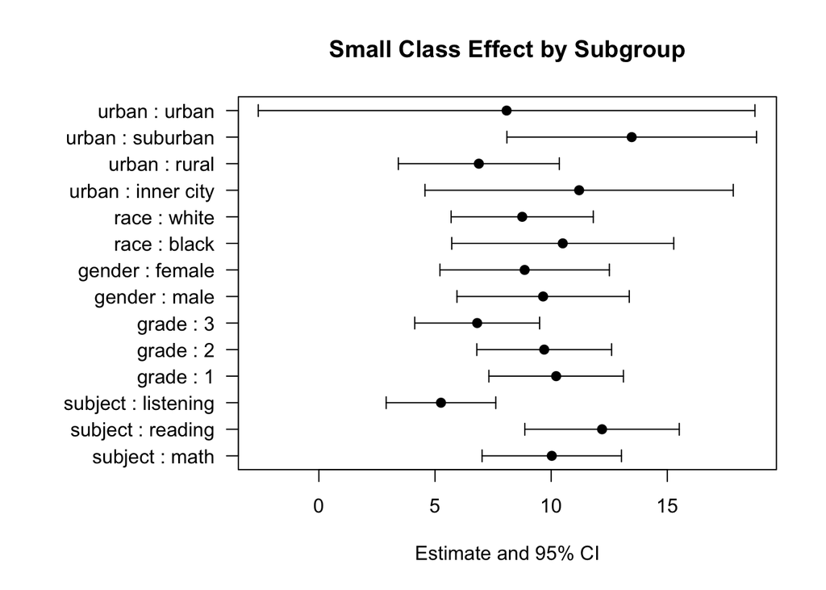

### Result

After controlling for individual student differences and the interaction between subjects and grades, we have determined that the benefits brought by small classes are tangible and real. Our research results confirm that small class size has a significant and positive causal impact on academic performance.

# Conclusion

Our analysis provide credible causal evidence that assignment to small classes increase SAT performance by around 10 points, and the estimate is robust across multiple model specifications and subgroups. This effect is not merely a short-term statistical improvement. In addition, prior studies using STAR project has shown that reducing the class size from approximately 22 students to 15 students can lead to a positive internal rate of return (about 5.5%), and also improves university examination results and narrows the racial gap in this regard.

From a financial perspective, it is complicated to accurately determine the cost associated with increasing one point per student. We need to collect more data and do more research in the future. So far, the research on Education Spending and Student Learning Outcomes generally suggests that a 10% increase in per-pupil spending results in a test score increase of roughly 0.05 to 0.09 standard deviations. In the 2025-2026 budget, Tennessee’s base funding is approximately $7,295 per student. To increase one point on their academic performance, the state would likely need to increase spending by roughly $730 to $1,000 per student, per year. Our analysis results reveal that implementing small classes can increase SAT performance by around 10 points, which costs approximately $7300 to $10,000 per student, per year. In Tennessee, there are approximately 1 million public school students. If such a plan is implemented across the state to boost academic performance through general funding, it would cost between 730 million and 1 billion US dollars annually. From other sources online, we found that for K-3, the yearly cost of small-class teaching is approximately $104k to $288K per year. This is very rough and depends on other local economic factors. In general, these rough comparisons indicate that achieving a comprehensive and statewide increase in funding sufficient to significantly improve test scores requires significant and ongoing budget commitments; while small class teaching is a more direct and mechanism-based investment, generating measurable returns at the schools.

# Reference

Achilles, C. M., Bain, H. P., Bellott, F., Boyd-Zaharias, J., Finn, J., Folger, J., Johnston, J., & Word, E. (2008). Tennessee’s Student Teacher Achievement Ratio (STAR) project (Version 1) [Data set]. Harvard Dataverse. https://doi.org/10.7910/DVN/SIWH9F

Evans, D. K., & Mendez Acosta, A. (2021, January 20). Education spending and student learning outcomes. World Bank Blogs. https://blogs.worldbank.org/en/impactevaluations/education-spending-and-student-learning-outcomes

Krueger, A. B., & Whitmore, D. M. (2000, April). The effect of attending a small class in the early grades on college-test taking and middle school test results: Evidence from Project STAR (NBER Working Paper No. 7656). National Bureau of Economic Research. https://doi.org/10.3386/w7656

National Center for Education Statistics. (2024, May). Public school expenditures. Condition of Education (U.S. Department of Education, Institute of Education Sciences). https://nces.ed.gov/programs/coe/indicator/cmb